# HW6 Cheat Sheet

This is a cheat sheet for the sixth homework on cohesion and community. It works through each step in R.

First, you need the following packages.

```r
library(igraph)
library(ggplot2)
library(Hmisc)
```

## 1. Introductory Inspection

Next, we bring the data into **igraph**. We have an igraph object stored as a .rds file. The data consist of an advice seeking network within a consulting firm: (“Please indicate how often you have turned to this person for information or advice on work-related topics in the past three months”). 0: I Do Not Know This Person; 1: Never; 2: Seldom; 3: Sometimes; 4: Often; and 5:Very Often.) Not knowing and never seeking advice edges have been dropped. The **igraph** objects include two attributes - gender (1: male; 2: female), region (1: Europe; 2: USA). You can learn more about the data [here](https://toreopsahl.com/datasets/#Cross_Parker).

```r
orgnet <- readRDS("data/orgnet.rds")

summary(orgnet)
```

```
IGRAPH 2fdca3c UNW- 44 320 --
+ attr: name (v/c), region (v/n), gender (v/n), weight (e/n)
```

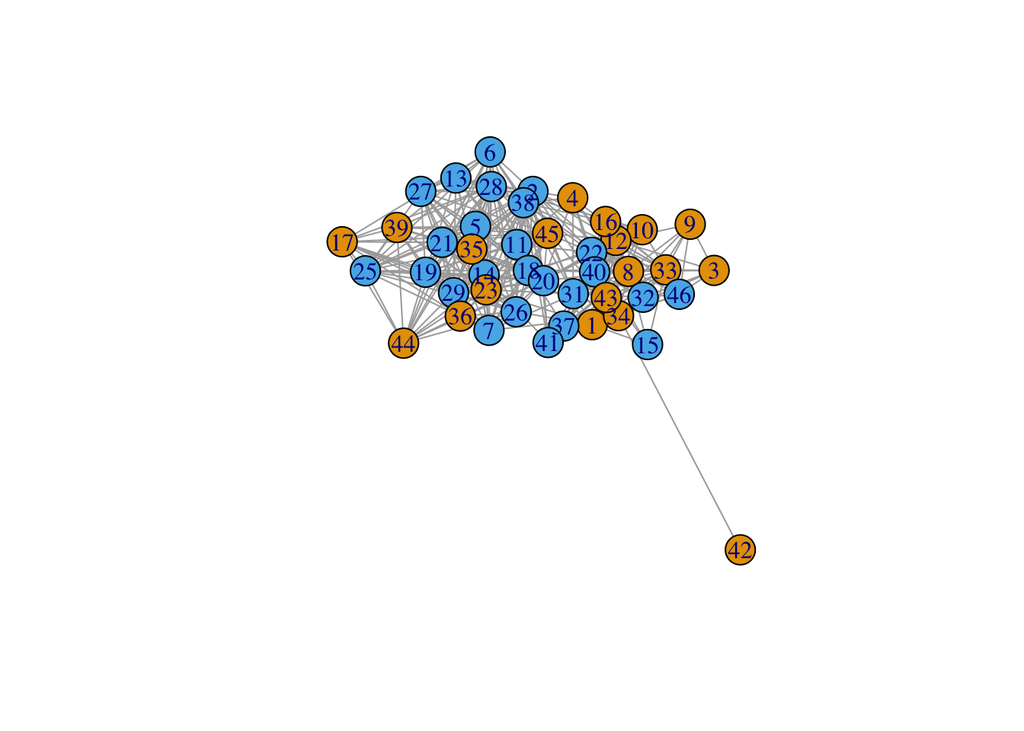

```r
layout.kk <- layout_with_kk(orgnet)

plot(orgnet, layout=layout.kk, vertex.color=V(orgnet)$region, edge.arrow.size=.1)
```

## 2. Components, Cliques, Cores, Cutpoints

Let’s start looking at some basic aspects of cohesion.

### i.Bicomponents

Here, we identify the largest bicomponet and then plot by region and gender.

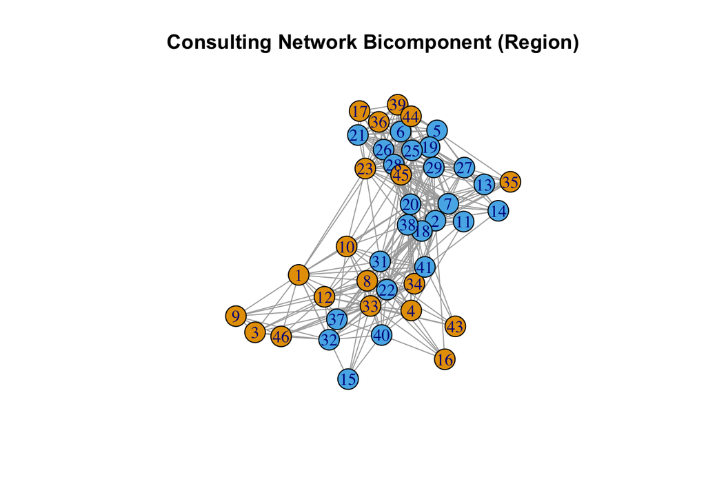

```r
bicomponent.org <- biconnected.components(orgnet)

b1 <- bicomponent.org$components[[max(length(bicomponent.org$components))]]

bi.g <- induced.subgraph(graph=orgnet,vids=b1)

plot.igraph(bi.g, vertex.color=V(orgnet)$region, main="Consulting Network Bicomponent (Region)")
```

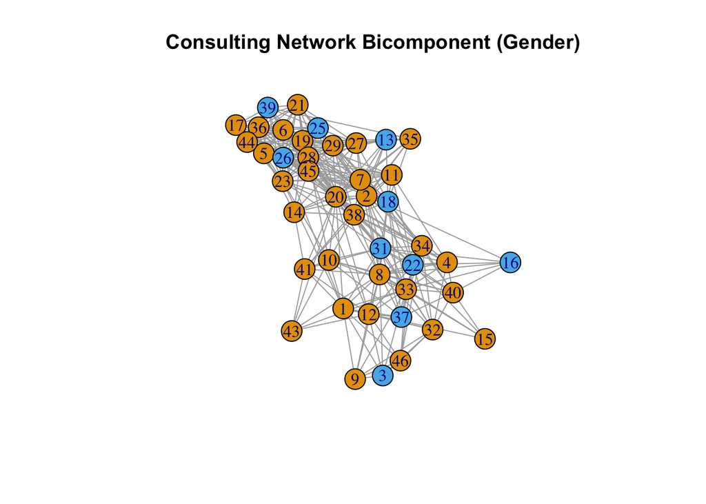

```r
plot.igraph(bi.g, vertex.color=V(orgnet)$gender, main="Consulting Network Bicomponent (Gender)")
```

### ii.Cliques

Next we identify the largest cliques (note that there may be several cliques of this size).

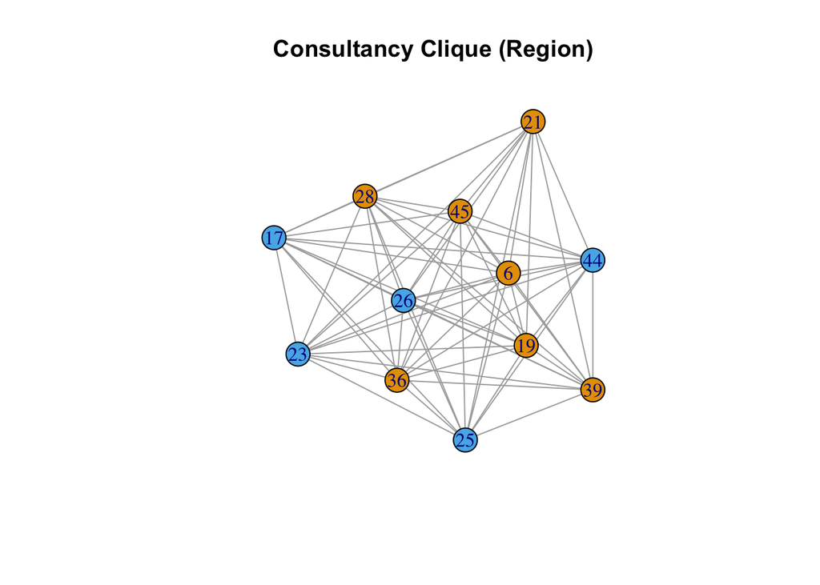

```r
cliques <- largest_cliques(orgnet)

c1 <- cliques[[max(length(cliques))]]

clique2 <- induced.subgraph(graph=orgnet,vids=c1)

plot(clique2, vertex.color=V(orgnet)$region, edge.arrow.size=.1, main="Consultancy Clique (Region)")
```

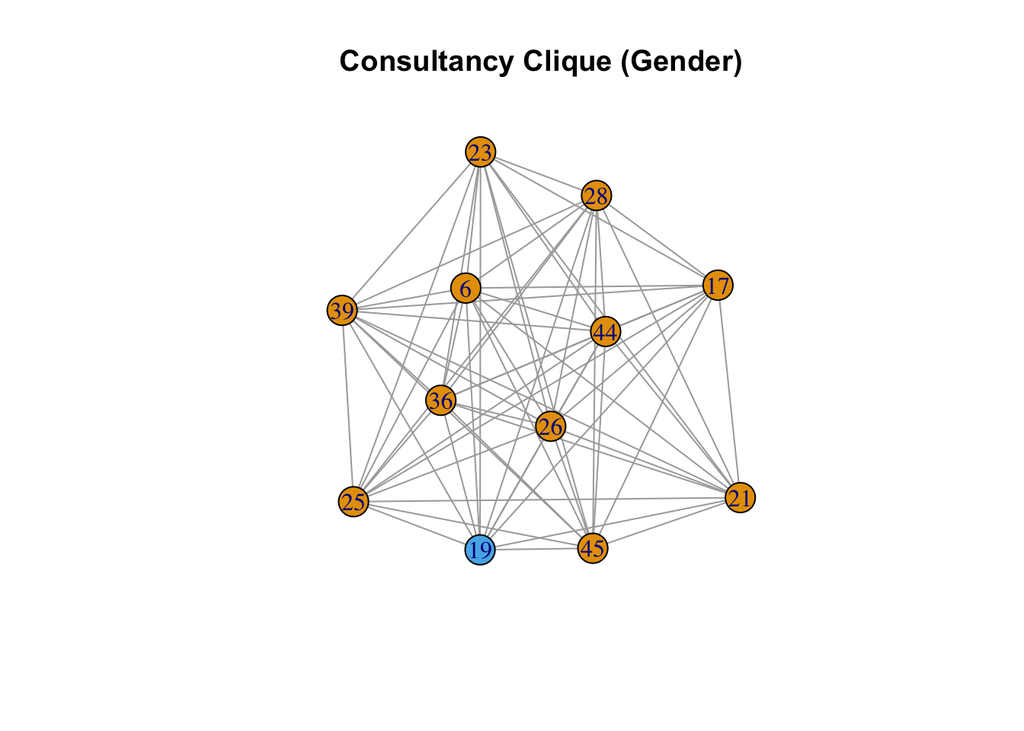

```r
plot(clique2, vertex.color=V(orgnet)$gender, edge.arrow.size=.1, main="Consultancy Clique (Gender)")
```

### iii.Cores

We can use table to simply find a distribution of cores.

```r
kcore <- coreness(orgnet)

table(kcore)
```

```
kcore
 1  5  6  7  9 10 11
 1  1  2  3 16  1 20
```

### iv.Cutpoints

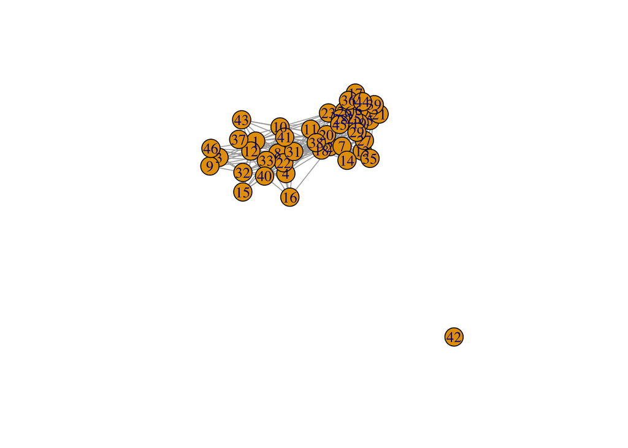

```r
art_points <- articulation.points(orgnet)

rem <- delete.vertices(orgnet, art_points)

plot(rem)
```

## 3. Extracting Subgraph

We didn’t need to plot the graphs to answer the questions in part 2, but as I already did this, we can just repeat.

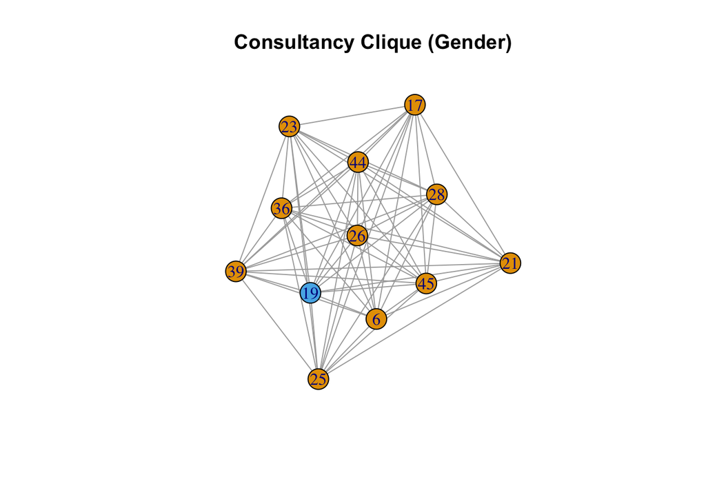

```r
plot(clique2, vertex.color=V(orgnet)$gender, edge.arrow.size=.1, main="Consultancy Clique (Gender)")
```

## 4. Communities

Now we turn to some community detection techniques on the largest bicomponent.

### a. Run Louvain, Walktrap, Leiden (high and low)

Can’t help but check really quickly, but next I will just make a data frame.

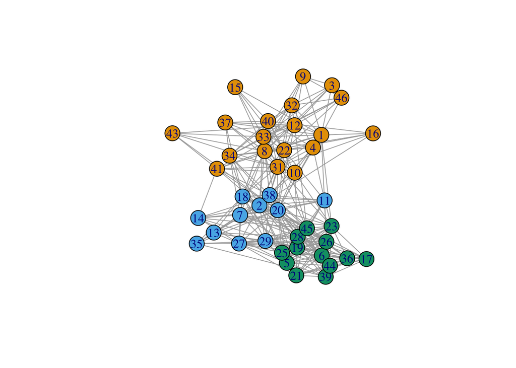

```r
lv_comms <- cluster_louvain(bi.g)

V(bi.g)$lv_comms <- lv_comms$membership

layout.big <- layout_with_fr(bi.g)

plot.igraph(bi.g, layout=layout.big, vertex.color=V(bi.g)$lv_comms)
```

OK. Let’s just look construct modularity and store for now.

```r
mod.df <- data.frame(louvain=
modularity(bi.g, cluster_louvain(bi.g)$membership),
walktrap=modularity(bi.g, cluster_walktrap(bi.g)$membership),
leiden_large=modularity(bi.g, cluster_leiden(bi.g, resolution_parameter = 2)$membership),
leiden_small=modularity(bi.g, cluster_leiden(bi.g, resolution_parameter = .5)$membership))


knitr::kable(mod.df)
```

| louvain | walktrap | leiden_large | leiden_small |
| --- | --- | --- | --- |
| 0.3262153 | 0.3262153 | 0.2529505 | 0.3114553 |

### Plot

We could use either Louvain or Walktrap. I’ll try Walktrap since I haven’t already constructed it although given the score they are very likely to be identical.

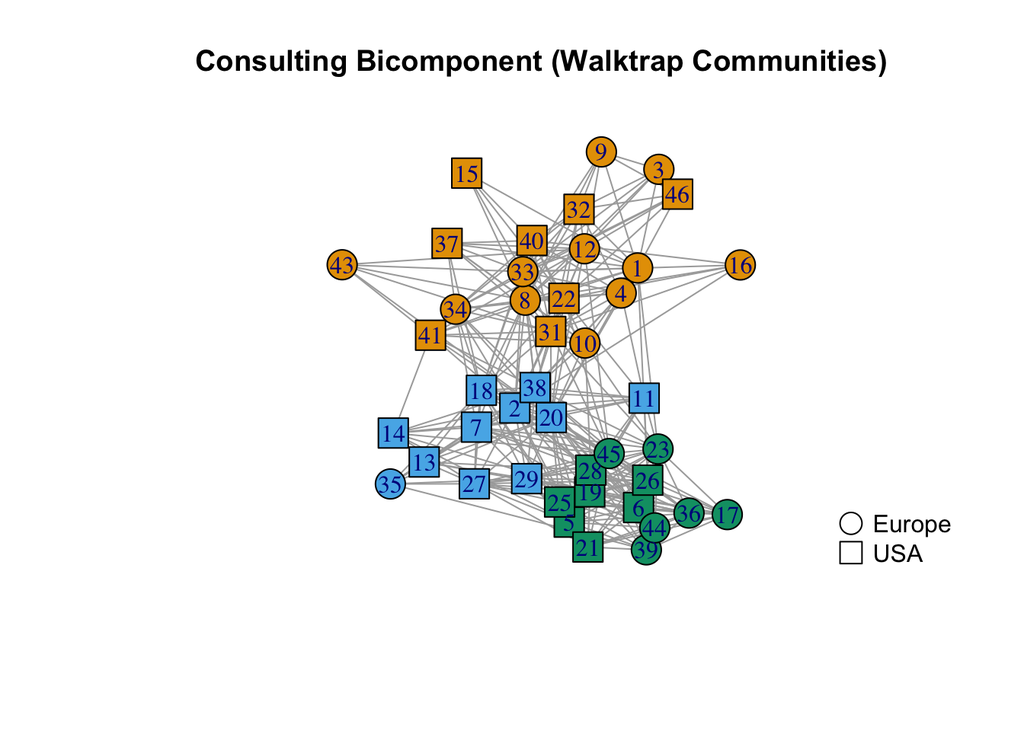

```r
V(bi.g)$walk <- cluster_walktrap(bi.g)$membership

shape <- c("circle", "square")

V(bi.g)$shape <- shape[as.factor(V(bi.g)$region)]

plot.igraph(bi.g, layout=layout.big, vertex.color=V(bi.g)$walk, vertex.shape=
              V(bi.g)$shape, main="Consulting Bicomponent (Walktrap Communities)")

legend("bottomright",
       c("Europe", "USA"),
pch=c(1,0) , bty = "n",pt.cex = 2, cex = 1)
```